# Intersections of Note

Ryan Porter

November 14, 2017

## Introduction

While working with this data I was interested to see if there was a way to identify common problems with intersections throughout the city.

The main way to do this would be looking at how intersections look compared to the average. So that is what I am going to look at first.

## Loading data and transforming it.

```r
df <- read.csv('data/traffic_accidents.csv')
intersections <- readLines('data/intersection.txt')

df <- df %>%
  mutate(inter_id = as.factor(intersections)) %>% # Adds a new column
  rename(lng = X, lat =Y) # Changes X and Y to lng and lat
```

First I load in the data from the Fredericton collisions data set, and then I load in a file that I created to combine point’s at the same intersection.

Then I tweak the data frame a little bit, adding a column of intersection IDs to each row. Also changing X and Y to lng and lat to work better with the mapping package I use.

## The average intersection

[below] This chart shows the average for the entire city. The most common type of collision back ending.

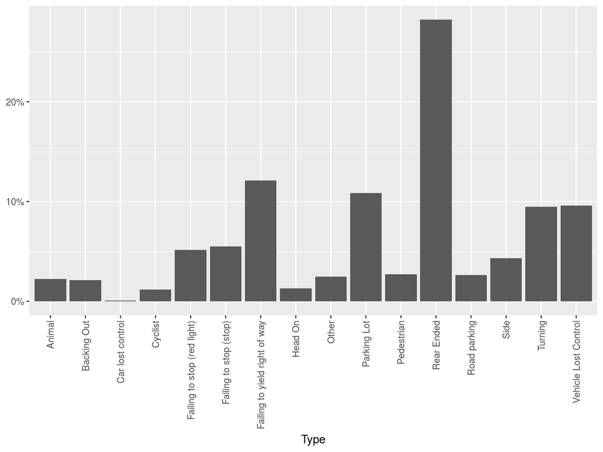

## Data wrangling

I think my next step is looking at how other intersections compare to the average intersection. and then cluster intersections that appear to be similar. So I will reshape the data to fit that need.

```r
#get a count of each type at each intersection.
inter_by_type <- dcast(df, inter_id ~ Type, fun.aggregate = length)
#select only the number columns of inter_by_type.
nums <- sapply(inter_by_type, is.numeric)
total <- rowSums(inter_by_type[ ,nums])
#create new dataframe with the averages for each intersection.
inter_by_type_avg <- inter_by_type
inter_by_type_avg[ ,nums] <- inter_by_type[ ,nums] / total
```

This will give us a data frame containing averages for each type of collision for all of Fredericton (at least the ones that show up in the data anyway!)

## Data wrangling (cont.)

Next I want to cluster the data by similar intersections and map the data. I’m going to look at 5 largest clusters of 15.

```r
#Run kmeans clustering with 15 centers
k <- kmeans(inter_by_type_avg[ ,nums], 15)
inter_by_type_avg <- mutate(inter_by_type_avg, cluster = k$cluster)

#get geo locations of each intersection
loc <- df %>%
  group_by(inter_id) %>%
  summarise(lng = mean(lng), lat = mean(lat)) %>%
  left_join(inter_by_type_avg, by="inter_id")

# get top 5
top5 <- loc %>%
  group_by(cluster) %>% summarise(total=n()) %>%
  arrange(-total) %>% head(5)
```

## Data wrangling (cont.)

```r
# select only the top 5 clusters
in_top5 <- loc$cluster %in% top5$cluster
loc_in_top5 <- loc[in_top5,]
```

It took a bit getting there but I can now map out the intersections in the 5 clusters that cover the most intersections.

## Charting the clusters

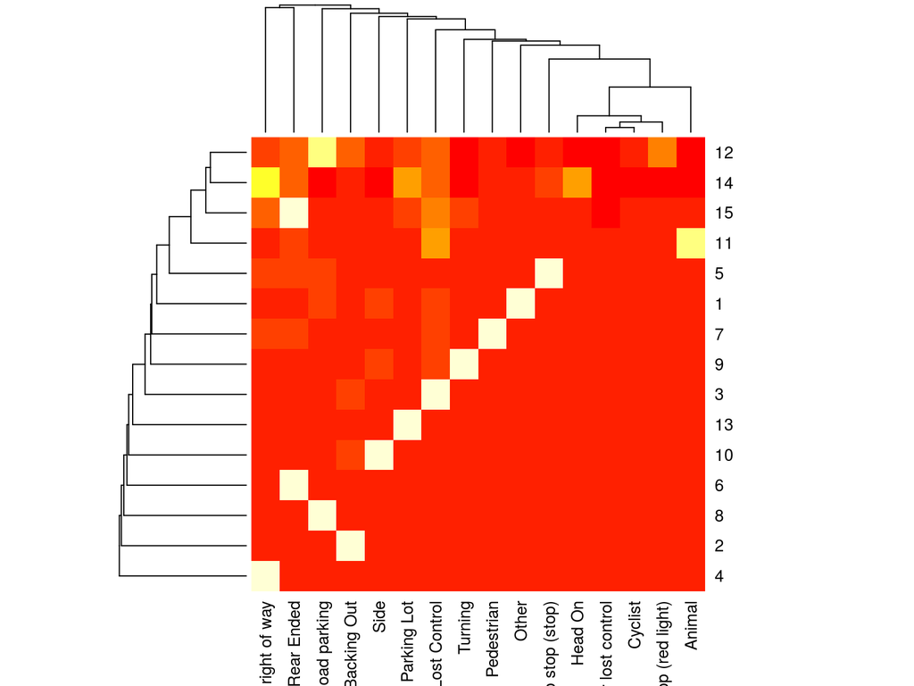

```r
heatmap( k$centers)
```

## The top 5

```r
print(top5)
```

```
## # A tibble: 5 x 2
##   cluster total
##     <int> <int>
## 1      15   189
## 2       6   100
## 3      14   100
## 4       3    81
## 5      12    64
```

these will correspond to red, yellow, green, blue and purple respectively on the next side.

## Mapped out

[interactive chart not shown]